# Risk Factor Analysis

## Outcome Variable

**Outcome Variable:** ever_sstunted

## Predictor Variables

**Intervention Variable:** parity

**Adjustment Set:**

- arm
- W_mage
- meducyrs
- feducyrs
- hhwealth_quart
- W_mhtcm
- W_mwtkg
- W_mbmi
- vagbrth
- W_nrooms
- impsan
- delta_W_mage
- delta_meducyrs
- delta_feducyrs
- delta_hhwealth_quart
- delta_W_mhtcm
- delta_W_mwtkg
- delta_W_mbmi
- delta_vagbrth
- delta_W_nrooms
- delta_impsan

## Stratifying Variables

The analysis was stratified on these variable(s):

- agecat
- studyid
- country

## Data Summary

| agecat | studyid | country | parity | ever_sstunted | n_cell | n |
| --- | --- | --- | --- | --- | --- | --- |
| 0-24 months | COHORTS | GUATEMALA | 1 | 0 | 121 | 1360 |
| 0-24 months | COHORTS | GUATEMALA | 1 | 1 | 92 | 1360 |
| 0-24 months | COHORTS | GUATEMALA | 2 | 0 | 105 | 1360 |
| 0-24 months | COHORTS | GUATEMALA | 2 | 1 | 87 | 1360 |
| 0-24 months | COHORTS | GUATEMALA | 3+ | 0 | 503 | 1360 |
| 0-24 months | COHORTS | GUATEMALA | 3+ | 1 | 452 | 1360 |
| 0-24 months | COHORTS | INDIA | 1 | 0 | 723 | 4630 |
| 0-24 months | COHORTS | INDIA | 1 | 1 | 89 | 4630 |
| 0-24 months | COHORTS | INDIA | 2 | 0 | 1061 | 4630 |
| 0-24 months | COHORTS | INDIA | 2 | 1 | 124 | 4630 |
| 0-24 months | COHORTS | INDIA | 3+ | 0 | 2205 | 4630 |
| 0-24 months | COHORTS | INDIA | 3+ | 1 | 428 | 4630 |
| 0-24 months | COHORTS | PHILIPPINES | 1 | 0 | 505 | 3058 |
| 0-24 months | COHORTS | PHILIPPINES | 1 | 1 | 173 | 3058 |
| 0-24 months | COHORTS | PHILIPPINES | 2 | 0 | 470 | 3058 |
| 0-24 months | COHORTS | PHILIPPINES | 2 | 1 | 220 | 3058 |
| 0-24 months | COHORTS | PHILIPPINES | 3+ | 0 | 994 | 3058 |
| 0-24 months | COHORTS | PHILIPPINES | 3+ | 1 | 696 | 3058 |
| 0-24 months | GMS-Nepal | NEPAL | 1 | 0 | 159 | 698 |
| 0-24 months | GMS-Nepal | NEPAL | 1 | 1 | 52 | 698 |
| 0-24 months | GMS-Nepal | NEPAL | 2 | 0 | 143 | 698 |
| 0-24 months | GMS-Nepal | NEPAL | 2 | 1 | 38 | 698 |
| 0-24 months | GMS-Nepal | NEPAL | 3+ | 0 | 227 | 698 |
| 0-24 months | GMS-Nepal | NEPAL | 3+ | 1 | 79 | 698 |
| 0-24 months | JiVitA-3 | BANGLADESH | 1 | 0 | 7949 | 27227 |
| 0-24 months | JiVitA-3 | BANGLADESH | 1 | 1 | 2303 | 27227 |
| 0-24 months | JiVitA-3 | BANGLADESH | 2 | 0 | 7618 | 27227 |
| 0-24 months | JiVitA-3 | BANGLADESH | 2 | 1 | 1381 | 27227 |
| 0-24 months | JiVitA-3 | BANGLADESH | 3+ | 0 | 6638 | 27227 |
| 0-24 months | JiVitA-3 | BANGLADESH | 3+ | 1 | 1338 | 27227 |

[output cut: 102 more lines]

The following strata were considered:

- agecat: 0-24 months, studyid: COHORTS, country: GUATEMALA
- agecat: 0-24 months, studyid: COHORTS, country: INDIA
- agecat: 0-24 months, studyid: COHORTS, country: PHILIPPINES
- agecat: 0-24 months, studyid: GMS-Nepal, country: NEPAL
- agecat: 0-24 months, studyid: JiVitA-3, country: BANGLADESH
- agecat: 0-24 months, studyid: Keneba, country: GAMBIA
- agecat: 0-24 months, studyid: PROVIDE, country: BANGLADESH
- agecat: 0-24 months, studyid: SAS-CompFeed, country: INDIA
- agecat: 0-24 months, studyid: SAS-FoodSuppl, country: INDIA
- agecat: 0-24 months, studyid: TanzaniaChild2, country: TANZANIA, UNITED REPUBLIC OF
- agecat: 0-24 months, studyid: ZVITAMBO, country: ZIMBABWE
- agecat: 0-6 months, studyid: COHORTS, country: GUATEMALA
- agecat: 0-6 months, studyid: COHORTS, country: INDIA
- agecat: 0-6 months, studyid: COHORTS, country: PHILIPPINES
- agecat: 0-6 months, studyid: GMS-Nepal, country: NEPAL
- agecat: 0-6 months, studyid: JiVitA-3, country: BANGLADESH
- agecat: 0-6 months, studyid: Keneba, country: GAMBIA
- agecat: 0-6 months, studyid: PROVIDE, country: BANGLADESH
- agecat: 0-6 months, studyid: SAS-CompFeed, country: INDIA
- agecat: 0-6 months, studyid: SAS-FoodSuppl, country: INDIA
- agecat: 0-6 months, studyid: TanzaniaChild2, country: TANZANIA, UNITED REPUBLIC OF
- agecat: 0-6 months, studyid: ZVITAMBO, country: ZIMBABWE

### Dropped Strata

Some strata were dropped due to rare outcomes:

- agecat: 0-24 months, studyid: SAS-FoodSuppl, country: INDIA
- agecat: 0-6 months, studyid: SAS-FoodSuppl, country: INDIA

## Methods Detail

We’re interested in the causal parameters $E[Y_a]$ for all values of $a \in \mathcal{A}$. These parameters represent the mean outcome if, possibly contrary to fact, we intervened to set all units to have $A=a$. Under the randomization and positivity assumptions, these are identified by the statistical parameters $\psi_a=E_W[E_{Y|A,W}(Y|A=a,W)]$. In addition, we’re interested in the mean of $Y$, $E[Y]$ under no intervention (the observed mean). We will estimate these parameters by using SuperLearner to fit the relevant likelihood factors – $E_{Y|A,W}(Y|A=a,W)$ and $p(A=a|W)$, and then updating our likelihood fit using a joint TMLE.

For unadjusted analyses ($W=\{\}$), initial likelihoods were estimated using Lrnr_glm to estimate the simple $E(Y|A)$ and Lrnr_mean to estimate $p(A)$. For adjusted analyses, a small library containing Lrnr_glmnet, Lrnr_xgboost, and Lrnr_mean was used.

Having estimated these parameters, we will then use the delta method to estimate relative risks and attributable risks relative to a prespecified baseline level of $A$.

# Results Detail

## Results Plots

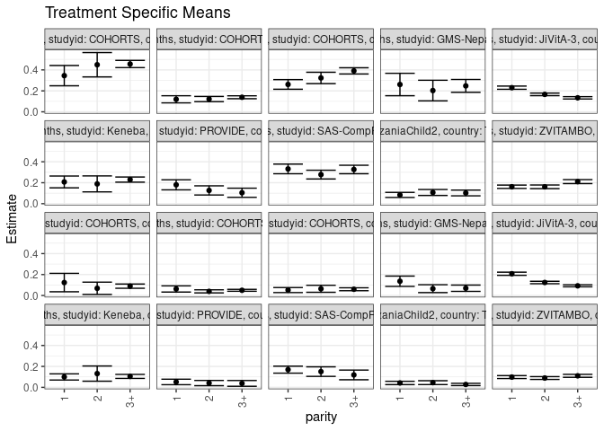

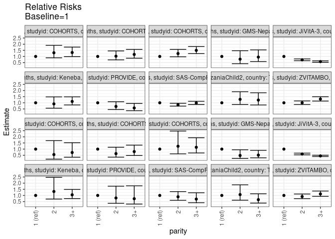

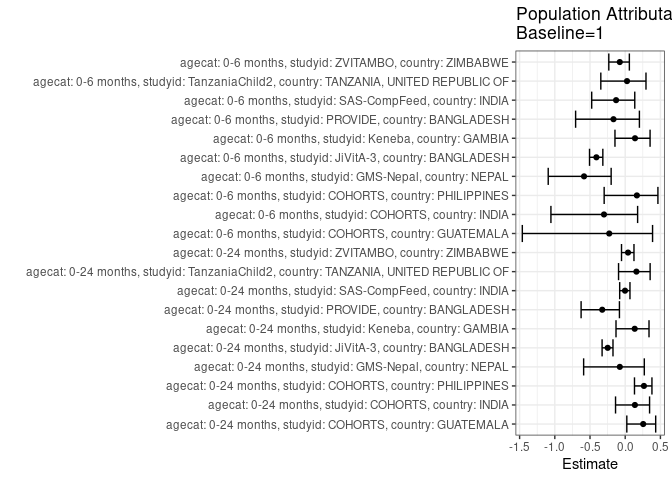

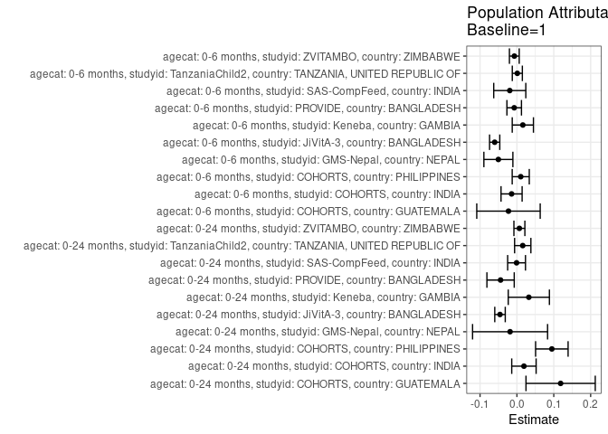

## Results Table

### Parameter: TSM

| agecat | studyid | country | intervention_level | baseline_level | estimate | ci_lower | ci_upper |
| --- | --- | --- | --- | --- | --- | --- | --- |
| 0-24 months | COHORTS | GUATEMALA | 1 | NA | 0.3454203 | 0.2485963 | 0.4422443 |
| 0-24 months | COHORTS | GUATEMALA | 2 | NA | 0.4492832 | 0.3330482 | 0.5655182 |
| 0-24 months | COHORTS | GUATEMALA | 3+ | NA | 0.4562993 | 0.4217646 | 0.4908341 |
| 0-24 months | COHORTS | INDIA | 1 | NA | 0.1193978 | 0.0853641 | 0.1534315 |
| 0-24 months | COHORTS | INDIA | 2 | NA | 0.1219169 | 0.0971012 | 0.1467327 |
| 0-24 months | COHORTS | INDIA | 3+ | NA | 0.1390303 | 0.1251484 | 0.1529122 |
| 0-24 months | COHORTS | PHILIPPINES | 1 | NA | 0.2613565 | 0.2154307 | 0.3072823 |
| 0-24 months | COHORTS | PHILIPPINES | 2 | NA | 0.3233977 | 0.2691314 | 0.3776639 |
| 0-24 months | COHORTS | PHILIPPINES | 3+ | NA | 0.3907820 | 0.3610483 | 0.4205157 |
| 0-24 months | GMS-Nepal | NEPAL | 1 | NA | 0.2606856 | 0.1537445 | 0.3676268 |
| 0-24 months | GMS-Nepal | NEPAL | 2 | NA | 0.2029989 | 0.1045235 | 0.3014743 |
| 0-24 months | GMS-Nepal | NEPAL | 3+ | NA | 0.2475484 | 0.1862202 | 0.3088766 |
| 0-24 months | JiVitA-3 | BANGLADESH | 1 | NA | 0.2303053 | 0.2149271 | 0.2456835 |
| 0-24 months | JiVitA-3 | BANGLADESH | 2 | NA | 0.1666025 | 0.1543520 | 0.1788530 |
| 0-24 months | JiVitA-3 | BANGLADESH | 3+ | NA | 0.1336901 | 0.1224251 | 0.1449551 |
| 0-24 months | Keneba | GAMBIA | 1 | NA | 0.2073784 | 0.1510443 | 0.2637125 |
| 0-24 months | Keneba | GAMBIA | 2 | NA | 0.1886666 | 0.1124612 | 0.2648721 |
| 0-24 months | Keneba | GAMBIA | 3+ | NA | 0.2297974 | 0.2052139 | 0.2543809 |
| 0-24 months | PROVIDE | BANGLADESH | 1 | NA | 0.1800406 | 0.1320156 | 0.2280655 |
| 0-24 months | PROVIDE | BANGLADESH | 2 | NA | 0.1264160 | 0.0827826 | 0.1700493 |
| 0-24 months | PROVIDE | BANGLADESH | 3+ | NA | 0.1043493 | 0.0606537 | 0.1480450 |
| 0-24 months | SAS-CompFeed | INDIA | 1 | NA | 0.3316637 | 0.2854251 | 0.3779023 |
| 0-24 months | SAS-CompFeed | INDIA | 2 | NA | 0.2774671 | 0.2355385 | 0.3193957 |
| 0-24 months | SAS-CompFeed | INDIA | 3+ | NA | 0.3263865 | 0.2859058 | 0.3668671 |
| 0-24 months | TanzaniaChild2 | TANZANIA, UNITED REPUBLIC OF | 1 | NA | 0.0834860 | 0.0592474 | 0.1077245 |
| 0-24 months | TanzaniaChild2 | TANZANIA, UNITED REPUBLIC OF | 2 | NA | 0.1068778 | 0.0784346 | 0.1353210 |
| 0-24 months | TanzaniaChild2 | TANZANIA, UNITED REPUBLIC OF | 3+ | NA | 0.1020490 | 0.0746643 | 0.1294338 |
| 0-24 months | ZVITAMBO | ZIMBABWE | 1 | NA | 0.1613950 | 0.1454786 | 0.1773114 |
| 0-24 months | ZVITAMBO | ZIMBABWE | 2 | NA | 0.1608322 | 0.1435523 | 0.1781121 |
| 0-24 months | ZVITAMBO | ZIMBABWE | 3+ | NA | 0.2105091 | 0.1916014 | 0.2294168 |
| 0-6 months | COHORTS | GUATEMALA | 1 | NA | 0.1236990 | 0.0358479 | 0.2115502 |
| 0-6 months | COHORTS | GUATEMALA | 2 | NA | 0.0688859 | 0.0100983 | 0.1276736 |
| 0-6 months | COHORTS | GUATEMALA | 3+ | NA | 0.0894151 | 0.0693318 | 0.1094984 |
| 0-6 months | COHORTS | INDIA | 1 | NA | 0.0625452 | 0.0329964 | 0.0920940 |
| 0-6 months | COHORTS | INDIA | 2 | NA | 0.0396024 | 0.0249295 | 0.0542753 |
| 0-6 months | COHORTS | INDIA | 3+ | NA | 0.0498594 | 0.0405820 | 0.0591367 |
| 0-6 months | COHORTS | PHILIPPINES | 1 | NA | 0.0520930 | 0.0280407 | 0.0761453 |
| 0-6 months | COHORTS | PHILIPPINES | 2 | NA | 0.0642382 | 0.0307699 | 0.0977065 |
| 0-6 months | COHORTS | PHILIPPINES | 3+ | NA | 0.0598258 | 0.0456585 | 0.0739930 |
| 0-6 months | GMS-Nepal | NEPAL | 1 | NA | 0.1362349 | 0.0870337 | 0.1854361 |
| 0-6 months | GMS-Nepal | NEPAL | 2 | NA | 0.0653140 | 0.0278145 | 0.1028135 |
| 0-6 months | GMS-Nepal | NEPAL | 3+ | NA | 0.0697103 | 0.0395387 | 0.0998820 |
| 0-6 months | JiVitA-3 | BANGLADESH | 1 | NA | 0.2076887 | 0.1927444 | 0.2226330 |
| 0-6 months | JiVitA-3 | BANGLADESH | 2 | NA | 0.1242768 | 0.1128178 | 0.1357359 |
| 0-6 months | JiVitA-3 | BANGLADESH | 3+ | NA | 0.0925562 | 0.0828641 | 0.1022484 |
| 0-6 months | Keneba | GAMBIA | 1 | NA | 0.0994182 | 0.0700008 | 0.1288357 |
| 0-6 months | Keneba | GAMBIA | 2 | NA | 0.1313623 | 0.0588313 | 0.2038932 |
| 0-6 months | Keneba | GAMBIA | 3+ | NA | 0.1045676 | 0.0852580 | 0.1238771 |
| 0-6 months | PROVIDE | BANGLADESH | 1 | NA | 0.0516605 | 0.0252890 | 0.0780320 |
| 0-6 months | PROVIDE | BANGLADESH | 2 | NA | 0.0409836 | 0.0160904 | 0.0658769 |
| 0-6 months | PROVIDE | BANGLADESH | 3+ | NA | 0.0378378 | 0.0103234 | 0.0653522 |
| 0-6 months | SAS-CompFeed | INDIA | 1 | NA | 0.1690563 | 0.1357724 | 0.2023401 |
| 0-6 months | SAS-CompFeed | INDIA | 2 | NA | 0.1503966 | 0.1048802 | 0.1959130 |
| 0-6 months | SAS-CompFeed | INDIA | 3+ | NA | 0.1188528 | 0.0726487 | 0.1650569 |
| 0-6 months | TanzaniaChild2 | TANZANIA, UNITED REPUBLIC OF | 1 | NA | 0.0421627 | 0.0263200 | 0.0580053 |
| 0-6 months | TanzaniaChild2 | TANZANIA, UNITED REPUBLIC OF | 2 | NA | 0.0450220 | 0.0265206 | 0.0635234 |
| 0-6 months | TanzaniaChild2 | TANZANIA, UNITED REPUBLIC OF | 3+ | NA | 0.0276386 | 0.0166975 | 0.0385797 |
| 0-6 months | ZVITAMBO | ZIMBABWE | 1 | NA | 0.0982506 | 0.0841449 | 0.1123563 |
| 0-6 months | ZVITAMBO | ZIMBABWE | 2 | NA | 0.0892258 | 0.0757898 | 0.1026619 |
| 0-6 months | ZVITAMBO | ZIMBABWE | 3+ | NA | 0.1101824 | 0.0960875 | 0.1242774 |

### Parameter: E(Y)

| agecat | studyid | country | intervention_level | baseline_level | estimate | ci_lower | ci_upper |
| --- | --- | --- | --- | --- | --- | --- | --- |
| 0-24 months | COHORTS | GUATEMALA | NA | NA | 0.4639706 | 0.4374564 | 0.4904847 |
| 0-24 months | COHORTS | INDIA | NA | NA | 0.1384449 | 0.1284958 | 0.1483940 |
| 0-24 months | COHORTS | PHILIPPINES | NA | NA | 0.3561151 | 0.3391405 | 0.3730897 |
| 0-24 months | GMS-Nepal | NEPAL | NA | NA | 0.2421203 | 0.2103189 | 0.2739218 |
| 0-24 months | JiVitA-3 | BANGLADESH | NA | NA | 0.1844493 | 0.1788538 | 0.1900447 |
| 0-24 months | Keneba | GAMBIA | NA | NA | 0.2396985 | 0.2209375 | 0.2584595 |
| 0-24 months | PROVIDE | BANGLADESH | NA | NA | 0.1357143 | 0.1103250 | 0.1611036 |
| 0-24 months | SAS-CompFeed | INDIA | NA | NA | 0.3307241 | 0.3024794 | 0.3589688 |
| 0-24 months | TanzaniaChild2 | TANZANIA, UNITED REPUBLIC OF | NA | NA | 0.0992787 | 0.0872038 | 0.1113537 |
| 0-24 months | ZVITAMBO | ZIMBABWE | NA | NA | 0.1681234 | 0.1619444 | 0.1743023 |
| 0-6 months | COHORTS | GUATEMALA | NA | NA | 0.1008249 | 0.0829501 | 0.1186997 |
| 0-6 months | COHORTS | INDIA | NA | NA | 0.0480662 | 0.0417969 | 0.0543355 |
| 0-6 months | COHORTS | PHILIPPINES | NA | NA | 0.0624591 | 0.0538810 | 0.0710373 |
| 0-6 months | GMS-Nepal | NEPAL | NA | NA | 0.0859599 | 0.0651504 | 0.1067694 |
| 0-6 months | JiVitA-3 | BANGLADESH | NA | NA | 0.1473804 | 0.1423344 | 0.1524264 |
| 0-6 months | Keneba | GAMBIA | NA | NA | 0.1154884 | 0.1009322 | 0.1300446 |
| 0-6 months | PROVIDE | BANGLADESH | NA | NA | 0.0442857 | 0.0290345 | 0.0595370 |
| 0-6 months | SAS-CompFeed | INDIA | NA | NA | 0.1496732 | 0.1307571 | 0.1685893 |
| 0-6 months | TanzaniaChild2 | TANZANIA, UNITED REPUBLIC OF | NA | NA | 0.0432754 | 0.0350591 | 0.0514916 |
| 0-6 months | ZVITAMBO | ZIMBABWE | NA | NA | 0.0912066 | 0.0864469 | 0.0959663 |

### Parameter: RR

| agecat | studyid | country | intervention_level | baseline_level | estimate | ci_lower | ci_upper |
| --- | --- | --- | --- | --- | --- | --- | --- |
| 0-24 months | COHORTS | GUATEMALA | 1 | 1 | 1.0000000 | 1.0000000 | 1.0000000 |
| 0-24 months | COHORTS | GUATEMALA | 2 | 1 | 1.3006855 | 0.8888077 | 1.9034296 |
| 0-24 months | COHORTS | GUATEMALA | 3+ | 1 | 1.3209973 | 0.9888559 | 1.7647000 |
| 0-24 months | COHORTS | INDIA | 1 | 1 | 1.0000000 | 1.0000000 | 1.0000000 |
| 0-24 months | COHORTS | INDIA | 2 | 1 | 1.0210988 | 0.7198829 | 1.4483503 |
| 0-24 months | COHORTS | INDIA | 3+ | 1 | 1.1644295 | 0.8617166 | 1.5734825 |
| 0-24 months | COHORTS | PHILIPPINES | 1 | 1 | 1.0000000 | 1.0000000 | 1.0000000 |
| 0-24 months | COHORTS | PHILIPPINES | 2 | 1 | 1.2373814 | 0.9720276 | 1.5751743 |
| 0-24 months | COHORTS | PHILIPPINES | 3+ | 1 | 1.4952069 | 1.2361536 | 1.8085485 |
| 0-24 months | GMS-Nepal | NEPAL | 1 | 1 | 1.0000000 | 1.0000000 | 1.0000000 |
| 0-24 months | GMS-Nepal | NEPAL | 2 | 1 | 0.7787117 | 0.4126037 | 1.4696715 |
| 0-24 months | GMS-Nepal | NEPAL | 3+ | 1 | 0.9496052 | 0.5880271 | 1.5335177 |
| 0-24 months | JiVitA-3 | BANGLADESH | 1 | 1 | 1.0000000 | 1.0000000 | 1.0000000 |
| 0-24 months | JiVitA-3 | BANGLADESH | 2 | 1 | 0.7233984 | 0.6556036 | 0.7982037 |
| 0-24 months | JiVitA-3 | BANGLADESH | 3+ | 1 | 0.5804907 | 0.5235884 | 0.6435770 |
| 0-24 months | Keneba | GAMBIA | 1 | 1 | 1.0000000 | 1.0000000 | 1.0000000 |
| 0-24 months | Keneba | GAMBIA | 2 | 1 | 0.9097696 | 0.5589987 | 1.4806489 |
| 0-24 months | Keneba | GAMBIA | 3+ | 1 | 1.1081065 | 0.8274435 | 1.4839685 |
| 0-24 months | PROVIDE | BANGLADESH | 1 | 1 | 1.0000000 | 1.0000000 | 1.0000000 |
| 0-24 months | PROVIDE | BANGLADESH | 2 | 1 | 0.7021527 | 0.4544003 | 1.0849871 |
| 0-24 months | PROVIDE | BANGLADESH | 3+ | 1 | 0.5795879 | 0.3536667 | 0.9498269 |
| 0-24 months | SAS-CompFeed | INDIA | 1 | 1 | 1.0000000 | 1.0000000 | 1.0000000 |
| 0-24 months | SAS-CompFeed | INDIA | 2 | 1 | 0.8365918 | 0.7300045 | 0.9587418 |
| 0-24 months | SAS-CompFeed | INDIA | 3+ | 1 | 0.9840886 | 0.8635849 | 1.1214073 |
| 0-24 months | TanzaniaChild2 | TANZANIA, UNITED REPUBLIC OF | 1 | 1 | 1.0000000 | 1.0000000 | 1.0000000 |
| 0-24 months | TanzaniaChild2 | TANZANIA, UNITED REPUBLIC OF | 2 | 1 | 1.2801886 | 0.8636369 | 1.8976527 |
| 0-24 months | TanzaniaChild2 | TANZANIA, UNITED REPUBLIC OF | 3+ | 1 | 1.2223498 | 0.8235115 | 1.8143510 |
| 0-24 months | ZVITAMBO | ZIMBABWE | 1 | 1 | 1.0000000 | 1.0000000 | 1.0000000 |
| 0-24 months | ZVITAMBO | ZIMBABWE | 2 | 1 | 0.9965129 | 0.8614789 | 1.1527130 |
| 0-24 months | ZVITAMBO | ZIMBABWE | 3+ | 1 | 1.3043098 | 1.1416549 | 1.4901387 |
| 0-6 months | COHORTS | GUATEMALA | 1 | 1 | 1.0000000 | 1.0000000 | 1.0000000 |
| 0-6 months | COHORTS | GUATEMALA | 2 | 1 | 0.5568832 | 0.1834000 | 1.6909422 |
| 0-6 months | COHORTS | GUATEMALA | 3+ | 1 | 0.7228441 | 0.3432194 | 1.5223603 |
| 0-6 months | COHORTS | INDIA | 1 | 1 | 1.0000000 | 1.0000000 | 1.0000000 |
| 0-6 months | COHORTS | INDIA | 2 | 1 | 0.6331812 | 0.3474571 | 1.1538647 |
| 0-6 months | COHORTS | INDIA | 3+ | 1 | 0.7971736 | 0.4799336 | 1.3241120 |
| 0-6 months | COHORTS | PHILIPPINES | 1 | 1 | 1.0000000 | 1.0000000 | 1.0000000 |
| 0-6 months | COHORTS | PHILIPPINES | 2 | 1 | 1.2331459 | 0.6157188 | 2.4697131 |
| 0-6 months | COHORTS | PHILIPPINES | 3+ | 1 | 1.1484428 | 0.6843704 | 1.9272030 |
| 0-6 months | GMS-Nepal | NEPAL | 1 | 1 | 1.0000000 | 1.0000000 | 1.0000000 |
| 0-6 months | GMS-Nepal | NEPAL | 2 | 1 | 0.4794220 | 0.2435248 | 0.9438278 |
| 0-6 months | GMS-Nepal | NEPAL | 3+ | 1 | 0.5116923 | 0.2913320 | 0.8987307 |
| 0-6 months | JiVitA-3 | BANGLADESH | 1 | 1 | 1.0000000 | 1.0000000 | 1.0000000 |
| 0-6 months | JiVitA-3 | BANGLADESH | 2 | 1 | 0.5983803 | 0.5332041 | 0.6715234 |
| 0-6 months | JiVitA-3 | BANGLADESH | 3+ | 1 | 0.4456489 | 0.3930838 | 0.5052434 |
| 0-6 months | Keneba | GAMBIA | 1 | 1 | 1.0000000 | 1.0000000 | 1.0000000 |
| 0-6 months | Keneba | GAMBIA | 2 | 1 | 1.3213094 | 0.7066669 | 2.4705535 |
| 0-6 months | Keneba | GAMBIA | 3+ | 1 | 1.0517946 | 0.7423090 | 1.4903118 |
| 0-6 months | PROVIDE | BANGLADESH | 1 | 1 | 1.0000000 | 1.0000000 | 1.0000000 |
| 0-6 months | PROVIDE | BANGLADESH | 2 | 1 | 0.7933255 | 0.3588172 | 1.7540002 |
| 0-6 months | PROVIDE | BANGLADESH | 3+ | 1 | 0.7324324 | 0.3012417 | 1.7808198 |
| 0-6 months | SAS-CompFeed | INDIA | 1 | 1 | 1.0000000 | 1.0000000 | 1.0000000 |
| 0-6 months | SAS-CompFeed | INDIA | 2 | 1 | 0.8896242 | 0.6024242 | 1.3137440 |
| 0-6 months | SAS-CompFeed | INDIA | 3+ | 1 | 0.7030368 | 0.4059761 | 1.2174628 |
| 0-6 months | TanzaniaChild2 | TANZANIA, UNITED REPUBLIC OF | 1 | 1 | 1.0000000 | 1.0000000 | 1.0000000 |
| 0-6 months | TanzaniaChild2 | TANZANIA, UNITED REPUBLIC OF | 2 | 1 | 1.0678159 | 0.6120771 | 1.8628875 |
| 0-6 months | TanzaniaChild2 | TANZANIA, UNITED REPUBLIC OF | 3+ | 1 | 0.6555232 | 0.3796910 | 1.1317379 |
| 0-6 months | ZVITAMBO | ZIMBABWE | 1 | 1 | 1.0000000 | 1.0000000 | 1.0000000 |
| 0-6 months | ZVITAMBO | ZIMBABWE | 2 | 1 | 0.9081454 | 0.7376488 | 1.1180496 |
| 0-6 months | ZVITAMBO | ZIMBABWE | 3+ | 1 | 1.1214428 | 0.9253500 | 1.3590900 |

### Parameter: PAR

| agecat | studyid | country | intervention_level | baseline_level | estimate | ci_lower | ci_upper |
| --- | --- | --- | --- | --- | --- | --- | --- |
| 0-24 months | COHORTS | GUATEMALA | 1 | NA | 0.1185503 | 0.0246113 | 0.2124892 |
| 0-24 months | COHORTS | INDIA | 1 | NA | 0.0190471 | -0.0140343 | 0.0521286 |
| 0-24 months | COHORTS | PHILIPPINES | 1 | NA | 0.0947586 | 0.0506782 | 0.1388390 |
| 0-24 months | GMS-Nepal | NEPAL | 1 | NA | -0.0185653 | -0.1202800 | 0.0831495 |
| 0-24 months | JiVitA-3 | BANGLADESH | 1 | NA | -0.0458560 | -0.0600761 | -0.0316360 |
| 0-24 months | Keneba | GAMBIA | 1 | NA | 0.0323201 | -0.0235071 | 0.0881472 |
| 0-24 months | PROVIDE | BANGLADESH | 1 | NA | -0.0443263 | -0.0813703 | -0.0072822 |
| 0-24 months | SAS-CompFeed | INDIA | 1 | NA | -0.0009396 | -0.0251088 | 0.0232296 |
| 0-24 months | TanzaniaChild2 | TANZANIA, UNITED REPUBLIC OF | 1 | NA | 0.0157928 | -0.0062980 | 0.0378836 |
| 0-24 months | ZVITAMBO | ZIMBABWE | 1 | NA | 0.0067284 | -0.0081330 | 0.0215897 |
| 0-6 months | COHORTS | GUATEMALA | 1 | NA | -0.0228741 | -0.1089098 | 0.0631616 |
| 0-6 months | COHORTS | INDIA | 1 | NA | -0.0144790 | -0.0430863 | 0.0141283 |
| 0-6 months | COHORTS | PHILIPPINES | 1 | NA | 0.0103662 | -0.0127839 | 0.0335162 |
| 0-6 months | GMS-Nepal | NEPAL | 1 | NA | -0.0502750 | -0.0896155 | -0.0109345 |
| 0-6 months | JiVitA-3 | BANGLADESH | 1 | NA | -0.0603082 | -0.0741597 | -0.0464568 |
| 0-6 months | Keneba | GAMBIA | 1 | NA | 0.0160701 | -0.0126865 | 0.0448268 |
| 0-6 months | PROVIDE | BANGLADESH | 1 | NA | -0.0073748 | -0.0271125 | 0.0123629 |
| 0-6 months | SAS-CompFeed | INDIA | 1 | NA | -0.0193831 | -0.0628814 | 0.0241152 |
| 0-6 months | TanzaniaChild2 | TANZANIA, UNITED REPUBLIC OF | 1 | NA | 0.0011127 | -0.0125329 | 0.0147582 |
| 0-6 months | ZVITAMBO | ZIMBABWE | 1 | NA | -0.0070440 | -0.0203158 | 0.0062278 |

### Parameter: PAF

| agecat | studyid | country | intervention_level | baseline_level | estimate | ci_lower | ci_upper |
| --- | --- | --- | --- | --- | --- | --- | --- |
| 0-24 months | COHORTS | GUATEMALA | 1 | NA | 0.2555124 | 0.0227350 | 0.4328440 |
| 0-24 months | COHORTS | INDIA | 1 | NA | 0.1375792 | -0.1373302 | 0.3460390 |
| 0-24 months | COHORTS | PHILIPPINES | 1 | NA | 0.2660899 | 0.1317133 | 0.3796702 |
| 0-24 months | GMS-Nepal | NEPAL | 1 | NA | -0.0766779 | -0.5905179 | 0.2711586 |
| 0-24 months | JiVitA-3 | BANGLADESH | 1 | NA | -0.2486106 | -0.3283773 | -0.1736338 |
| 0-24 months | Keneba | GAMBIA | 1 | NA | 0.1348363 | -0.1307958 | 0.3380695 |
| 0-24 months | PROVIDE | BANGLADESH | 1 | NA | -0.3266146 | -0.6265173 | -0.0820090 |
| 0-24 months | SAS-CompFeed | INDIA | 1 | NA | -0.0028410 | -0.0785051 | 0.0675147 |
| 0-24 months | TanzaniaChild2 | TANZANIA, UNITED REPUBLIC OF | 1 | NA | 0.1590752 | -0.0945608 | 0.3539376 |
| 0-24 months | ZVITAMBO | ZIMBABWE | 1 | NA | 0.0400203 | -0.0525361 | 0.1244376 |
| 0-6 months | COHORTS | GUATEMALA | 1 | NA | -0.2268695 | -1.4615782 | 0.3885188 |
| 0-6 months | COHORTS | INDIA | 1 | NA | -0.3012302 | -1.0552404 | 0.1761547 |
| 0-6 months | COHORTS | PHILIPPINES | 1 | NA | 0.1659672 | -0.2990348 | 0.4645172 |
| 0-6 months | GMS-Nepal | NEPAL | 1 | NA | -0.5848656 | -1.0936138 | -0.1997432 |
| 0-6 months | JiVitA-3 | BANGLADESH | 1 | NA | -0.4092012 | -0.5068617 | -0.3178701 |
| 0-6 months | Keneba | GAMBIA | 1 | NA | 0.1391495 | -0.1455556 | 0.3530967 |
| 0-6 months | PROVIDE | BANGLADESH | 1 | NA | -0.1665278 | -0.7044880 | 0.2016446 |
| 0-6 months | SAS-CompFeed | INDIA | 1 | NA | -0.1295027 | -0.4760039 | 0.1356552 |
| 0-6 months | TanzaniaChild2 | TANZANIA, UNITED REPUBLIC OF | 1 | NA | 0.0257116 | -0.3465836 | 0.2950769 |
| 0-6 months | ZVITAMBO | ZIMBABWE | 1 | NA | -0.0772311 | -0.2330885 | 0.0589265 |